# Homework1

Dorukhan Kılınç - IE360 - Fall 2020

# Data Visualization

## 1) Yearly Divorce Numbers of Istanbul from 2010 to 2019

Yearly divorce numbers are taken from TUIK.

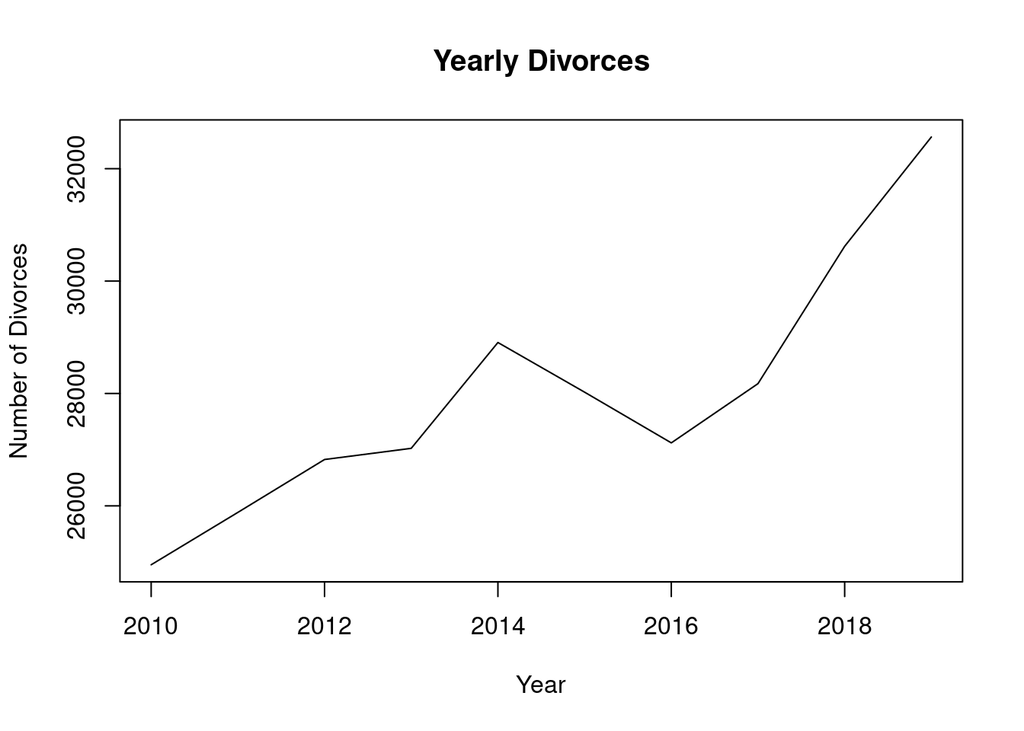

I used “boşanma davası” as google trends search keyword for this data.

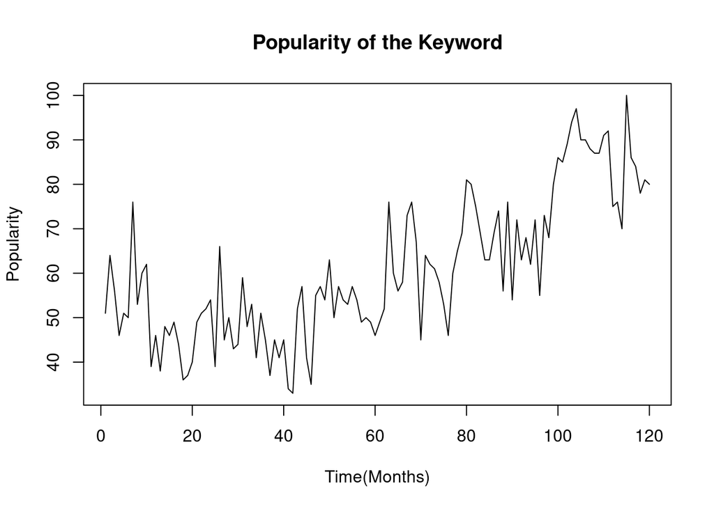

Boxplot two measures together:

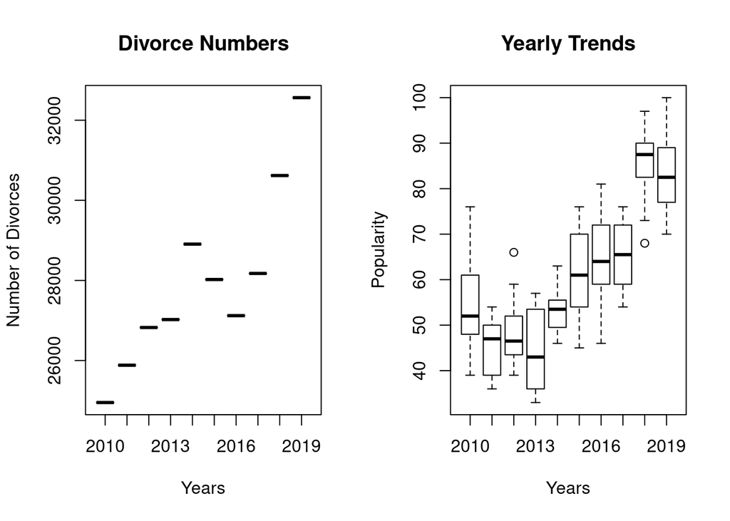

Looking by two boxplots, we can say that there is some kind of correlation between divorce numbers and the trend of the keyword since yearly trends seems to reflect the change in the divorce numbers such that high popularity resulting in increasing and low popularity resulting in non-increasing behavior.

## 2) Birth Numbers from 2009 to 2019

Monthly birth values from 2009 to 2019 are taken from TUIK.

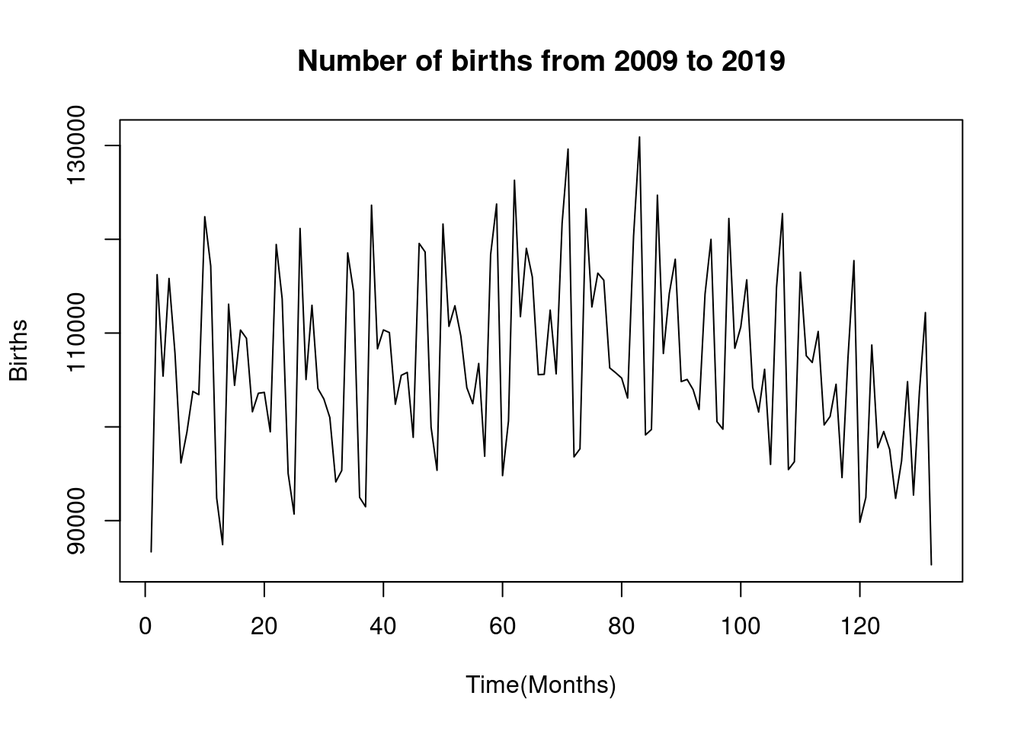

Number of births tend to have a yearly cyclic behavior.

For this measure, I chose the search keyword as “bebek kıyafetleri”.

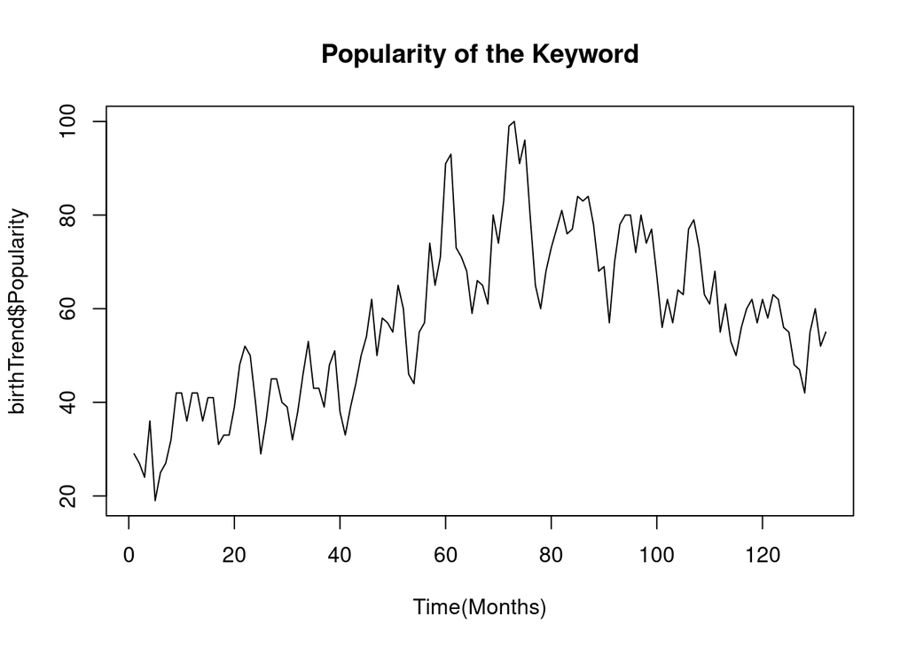

Notice that popularity of the keyword also shows a kind of yearly cyclic behavior.

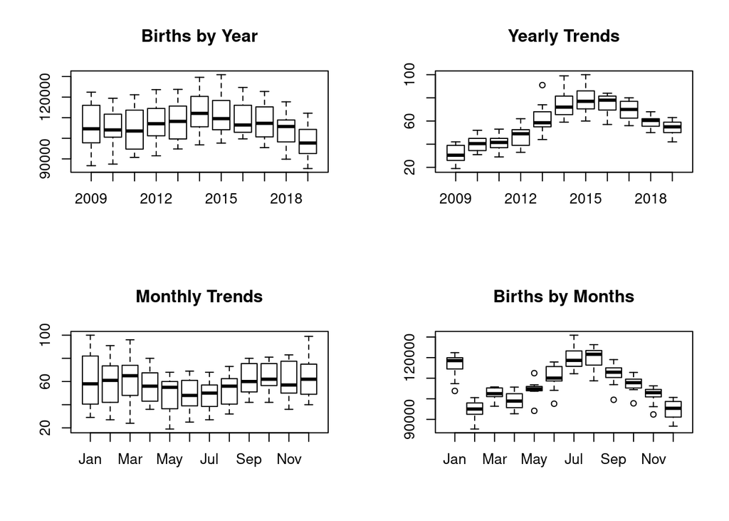

While yearly boxplots of the measures seem to have same behavior in that they both increase first and then decrease, change in the yearly trends is more dramatic. This is may be because of the fact that once a baby is born his/her need for baby clothing will stay for some years and therefore, each birth will cumulatively affect the search trend of the keyword.

Because both monthly trends and births seemed to have cyclic behavior, I also plotted them. However, there appears no visual correlation between them.

## 3) Popularity of Cinema from 2004 to 2019

Measures are taken from TUIK.

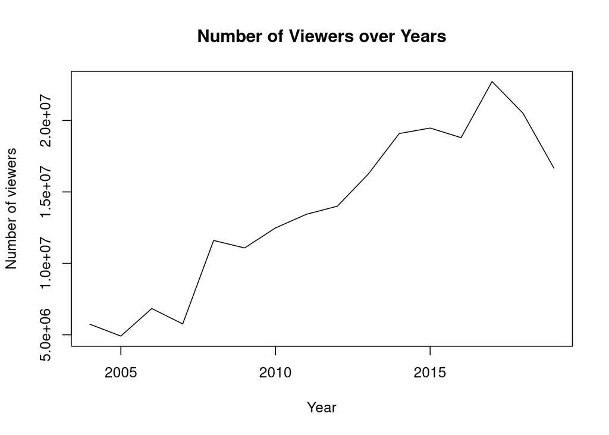

Cinema in Turkey seems to gain popularity over years and lose some at the end. This may be a reflection of continuously increasing prices.

I chose “vizyondaki filmler” as google trends search keyword.

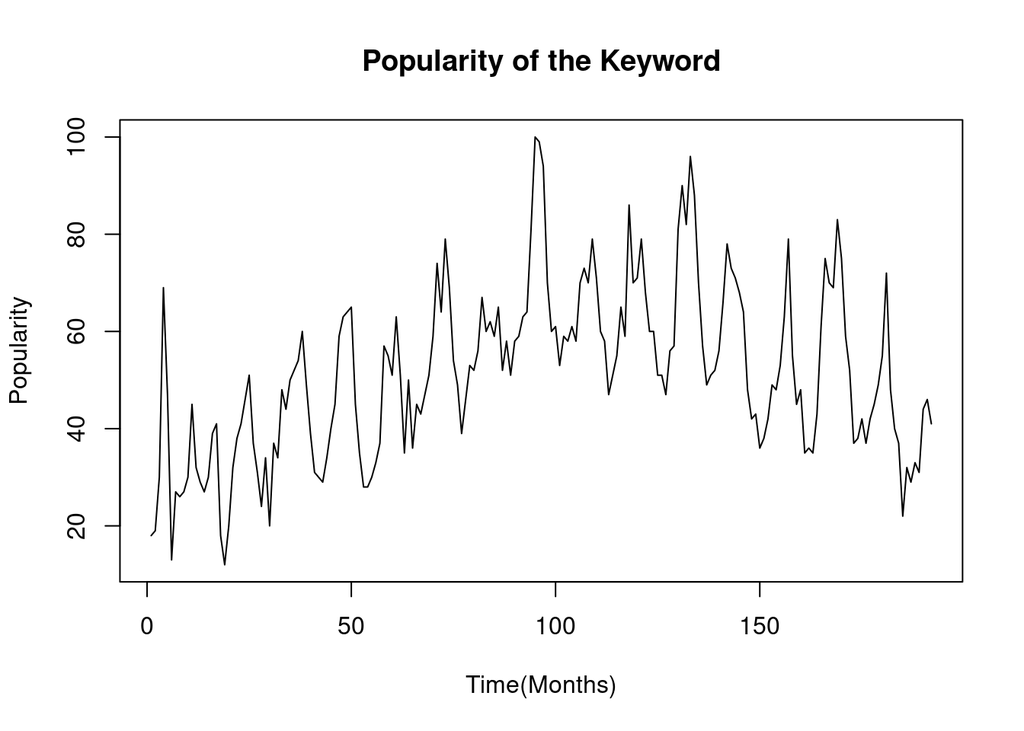

Popularity of the keyword shows seasonal changes. One of the reasons of that may be the fact that most of the hollywood big budget films are shown in cinemas during summer.

To compare this two measures we plot boxplots:

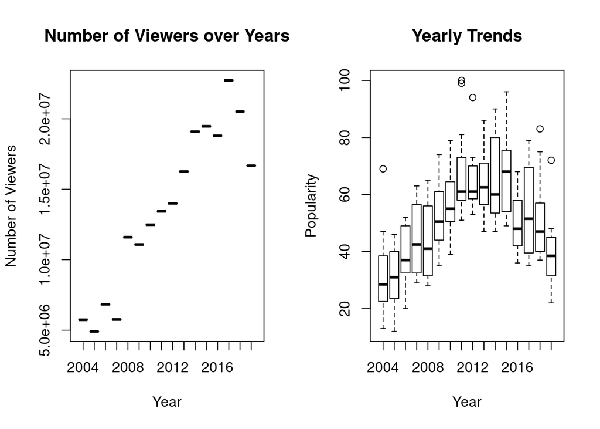

It seems that, to some extent, direction of change in the number of viewers over years can be guessed from the change in the yearly trends. However they are not identical measures. This can be because of the fact that searching through internet is not the only option of finding out what is being shown in the cinemas. In addition, the trends data after 2015 successfully predicts the lose of some interest to cinema. We can say that these two data measures are related.

#### References

[Google Trends](https://trends.google.com/trends/?geo=TR) / [TUIK](https://www.tuik.gov.tr/)